# EDA

Exploratory Data Analysis (EDA) Report

To begin the analysis, we first inspect the dataset by checking its dimensions, previewing a few initial rows, and examining the data types of each column. This step is crucial to understanding the structure of the dataset and ensuring that the data is in the correct format for further processing. The dataset consists of several columns, including county names, state names, and monthly home values recorded over time. By identifying potential data type inconsistencies at this stage, we can preemptively handle any formatting issues that may arise in later computations. The preview of the first few rows also allows us to get a sense of the dataset's organization and confirm whether all necessary columns are present.

```python
# Step 1: Import Required Libraries
import pandas as pd
import numpy as np
import matplotlib.pyplot as plt
import seaborn as sns
from statsmodels.tsa.seasonal import seasonal_decompose
```

```python
from google.colab import files
uploaded = files.upload()
df = pd.read_csv('/content/County_zhvi_bdrmcnt_3_uc_sfrcondo_tier_0.33_0.67_sm_sa_month (1).csv')
```

Upload widget is only available when the cell has been executed in the current browser session. Please rerun this cell to enable.

```
Saving County_zhvi_bdrmcnt_3_uc_sfrcondo_tier_0.33_0.67_sm_sa_month (1).csv to County_zhvi_bdrmcnt_3_uc_sfrcondo_tier_0.33_0.67_sm_sa_month (1).csv
```

```python
print("Dataset Shape:", df.shape)
print("\nFirst 3 Rows:")
display(df.head(3))
print("\nColumn Data Types:")
print(df.dtypes)
```

```
Dataset Shape: (2802, 309)

First 3 Rows:
```

|  | RegionID | SizeRank | RegionName | RegionType | StateName | State | Metro | StateCodeFIPS | MunicipalCodeFIPS | 2000-01-31 | ... | 2024-03-31 | 2024-04-30 | 2024-05-31 | 2024-06-30 | 2024-07-31 | 2024-08-31 | 2024-09-30 | 2024-10-31 | 2024-11-30 | 2024-12-31 |
| --- | --- | --- | --- | --- | --- | --- | --- | --- | --- | --- | --- | --- | --- | --- | --- | --- | --- | --- | --- | --- | --- |
| 0 | 3101 | 0 | Los Angeles County | county | CA | CA | Los Angeles-Long Beach-Anaheim, CA | 6 | 37 | 201205.779162 | ... | 824502.191810 | 825453.940899 | 828783.753915 | 831200.005473 | 835048.873969 | 840401.852474 | 847039.786778 | 852193.028434 | 856262.042894 | 859544.410854 |
| 1 | 139 | 1 | Cook County | county | IL | IL | Chicago-Naperville-Elgin, IL-IN-WI | 17 | 31 | 137238.240267 | ... | 300293.564189 | 303448.748969 | 305860.274871 | 307392.974488 | 308401.174854 | 309362.770197 | 310259.196138 | 310929.381417 | 311826.766306 | 312910.363938 |
| 2 | 1090 | 2 | Harris County | county | TX | TX | Houston-The Woodlands-Sugar Land, TX | 48 | 201 | 94529.400935 | ... | 255015.218344 | 255894.418621 | 256424.422257 | 256316.109051 | 256008.637545 | 255655.450257 | 255370.603778 | 254903.912966 | 254378.403656 | 254101.747895 |

3 rows × 309 columns

```
Column Data Types:
RegionID        int64
SizeRank        int64
RegionName     object
RegionType     object
StateName      object
               ...
2024-08-31    float64
2024-09-30    float64
2024-10-31    float64
2024-11-30    float64
2024-12-31    float64
Length: 309, dtype: object
```

Filtering Dataset for 2020-Present

Since real estate markets fluctuate significantly over time, this analysis focuses only on recent data from January 2020 onwards. To achieve this, we extract only the relevant date columns while retaining essential location identifiers such as the county and state names. This filtering ensures that the analysis remains current and relevant, as older data may not accurately reflect the trends driving today's housing market. By narrowing down the timeframe, we can better understand post-pandemic price trends, which have been a crucial factor in real estate market shifts.

```python
date_columns = [col for col in df.columns if pd.to_datetime(col, errors='coerce') >= pd.to_datetime('2020-01-01')]
df_filtered = df[['RegionName', 'StateName'] + date_columns]
```

```python
df_melted = df_filtered.melt(id_vars=['RegionName', 'StateName'],
                            var_name='Date',
                            value_name='Value')
df_melted['Date'] = pd.to_datetime(df_melted['Date'])
df_melted = df_melted.sort_values(['RegionName', 'Date'])
```

3. Handling Missing Values

```python
print("\nMissing Values Before Handling:", df_melted['Value'].isna().sum())
df_melted['Value'] = df_melted.groupby('RegionName')['Value'].ffill()
print("Missing Values After Handling:", df_melted['Value'].isna().sum())
```

```
Missing Values Before Handling: 366
Missing Values After Handling: 228
```

Descriptive Statistics

A detailed statistical summary of home values provides critical insights into the data distribution. Key metrics such as mean, median, standard deviation, and minimum/maximum values highlight differences across counties. For instance, counties with high mean values generally represent expensive housing markets, while high standard deviations suggest greater volatility in prices. Understanding these statistics allows us to differentiate stable markets from highly fluctuating ones, which can influence investment decisions and policy-making.

```
Descriptive Statistics (2020-Present):
```

| RegionName | count | mean | std | min | 25% | 50% | 75% | max |
| --- | --- | --- | --- | --- | --- | --- | --- | --- |
| Abbeville County | 60.0 | 181208.095410 | 31789.592783 | 126054.434761 | 155261.427237 | 191482.514543 | 208575.888265 | 225217.428976 |
| Acadia Parish | 60.0 | 164223.065647 | 12766.837315 | 143309.539933 | 151224.534212 | 171446.653667 | 174781.175192 | 179703.404186 |
| Accomack County | 60.0 | 237528.288850 | 39590.365806 | 169882.301373 | 205050.778096 | 247457.970856 | 269948.242010 | 294112.574423 |
| Ada County | 60.0 | 433212.193502 | 58622.228519 | 306292.735348 | 418958.972335 | 453946.736068 | 469319.026822 | 506644.361830 |
| Adair County | 240.0 | 148313.185527 | 23658.047885 | 94801.766452 | 130970.702768 | 150207.741492 | 169305.661165 | 187587.696709 |
| ... | ... | ... | ... | ... | ... | ... | ... | ... |
| York County | 300.0 | 293211.768852 | 98129.393710 | 142975.490021 | 207005.496491 | 280710.804162 | 348951.268221 | 519833.497507 |
| Young County | 60.0 | 148478.189668 | 25803.139559 | 104442.446846 | 123846.159853 | 160841.386745 | 171497.508307 | 177425.352355 |
| Yuba County | 60.0 | 353974.811929 | 38770.220205 | 277692.944546 | 326137.527082 | 371543.338970 | 383791.694626 | 394756.680253 |
| Yuma County | 120.0 | 218892.970030 | 33266.468868 | 159583.522444 | 189158.806653 | 225640.527356 | 247778.647721 | 265774.822832 |
| Zavala County | 60.0 | 90195.325237 | 11893.907267 | 68590.850222 | 81624.544587 | 95257.464581 | 98786.727156 | 104909.413404 |

1683 rows × 8 columns

Distributions

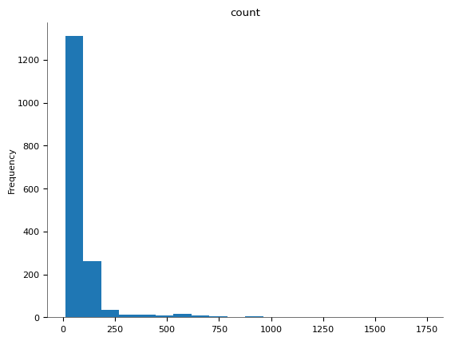

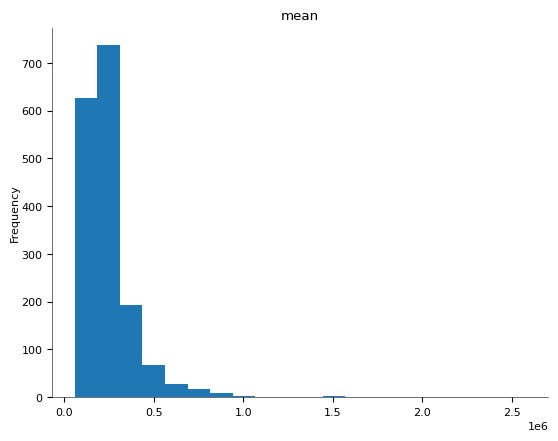

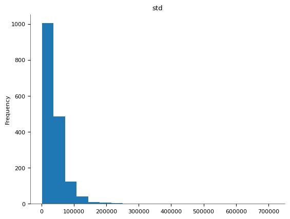

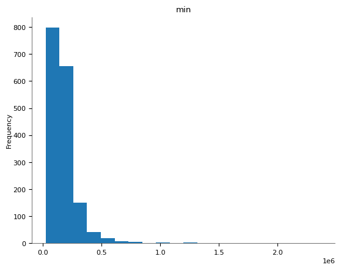

2-d distributions

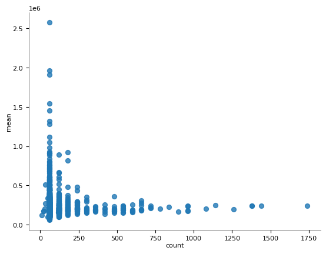

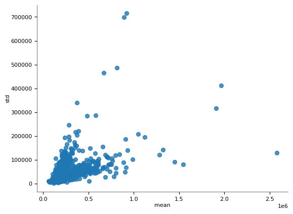

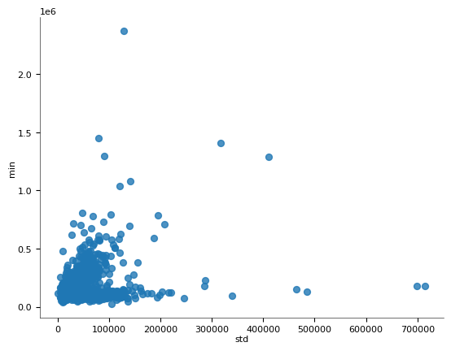

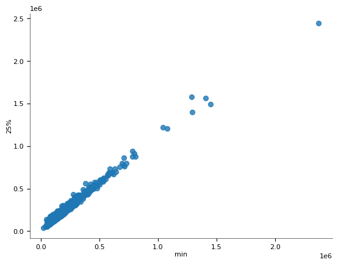

Values

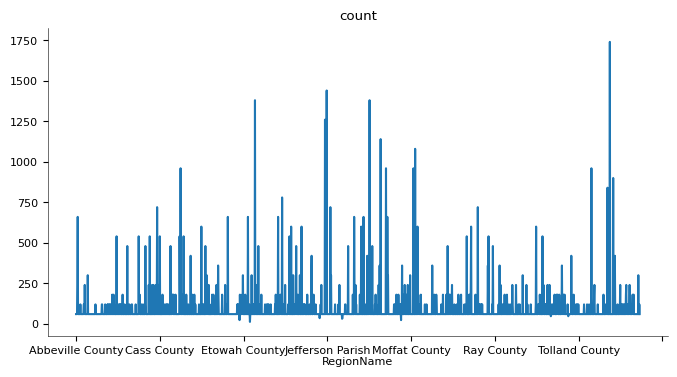

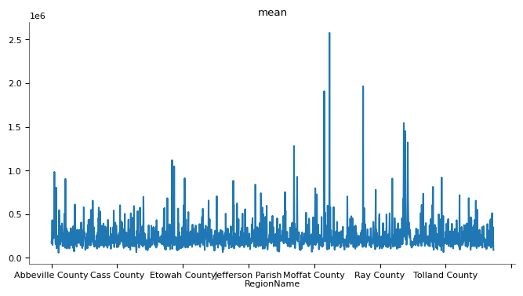

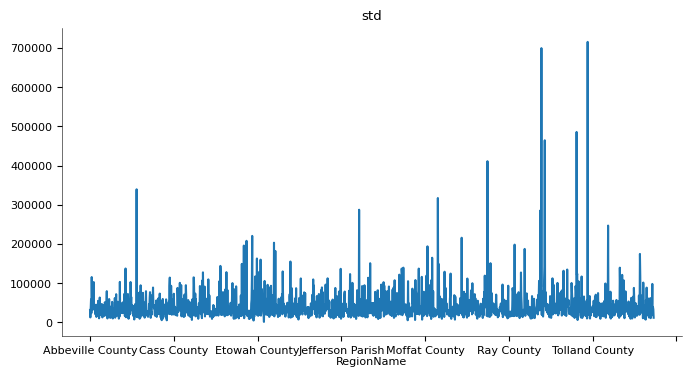

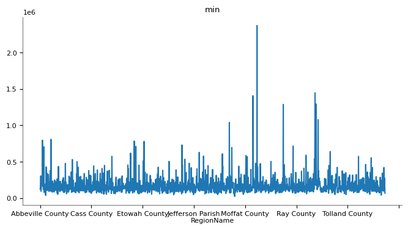

```python
stats = df_melted.groupby('RegionName')['Value'].describe()
print("\nDescriptive Statistics (2020-Present):")
display(stats)
```

Identifying Fastest-Growing Counties

One of the primary goals of this analysis is to identify counties with the highest growth rates in home values from 2020 to the present. By calculating the percentage increase from the first available value in 2020 to the latest recorded value, we determine which counties have experienced the most rapid price appreciation. The top-growing markets often attract investors and homebuyers looking for appreciation potential. These areas may also be experiencing economic growth, population influx, or infrastructure improvements, contributing to rising home values.

```python
latest_values = df_melted.groupby('RegionName').last()['Value']
initial_values = df_melted.groupby('RegionName').first()['Value']
growth_rates = ((latest_values - initial_values)/initial_values * 100).sort_values(ascending=False)

print("\nTop 5 Counties by Growth Rate:")
display(growth_rates.head(5))
```

```
Top 5 Counties by Growth Rate:
```

| RegionName | Value |
| --- | --- |
| San Miguel County | 949.392535 |
| Summit County | 832.125599 |
| Madison County | 311.205730 |
| Northumberland County | 309.671188 |
| Menominee County | 297.346588 |

**dtype:** float64

Identifying the Most Volatile Markets

Real estate volatility refers to how much home values fluctuate over time. By computing the standard deviation of home values for each county, we identify the most unstable markets. High volatility can be both an opportunity and a risk—investors may find profit in highly fluctuating markets, but homebuyers seeking long-term stability might prefer low-volatility areas. Understanding which counties exhibit the greatest variability can help stakeholders make informed decisions about market entry and exit strategies.

```python
volatility = df_melted.groupby('RegionName')['Value'].std().sort_values(ascending=False)
print("\nTop 5 Most Volatile Markets:")
display(volatility.head(5))
```

```
Top 5 Most Volatile Markets:
```

| RegionName | Value |
| --- | --- |
| Teton County | 715185.938670 |
| San Miguel County | 699271.772562 |
| Summit County | 485554.348262 |
| Santa Cruz County | 464347.449135 |
| Pitkin County | 411028.805050 |

**dtype:** float64

Growth Acceleration Analysis (Maricopa County)

In addition to analyzing growth rates, we also calculate growth acceleration, which measures the change in growth rates over time. This metric is particularly useful for identifying markets that are either gaining or losing momentum. For this analysis, Maricopa County is selected as a case study. By computing both the month-over-month growth rate and its first derivative (acceleration), we gain deeper insights into whether home value growth is speeding up, slowing down, or stabilizing. This kind of analysis is valuable for identifying emerging trends before they become widely recognized.

```python
# Calculate monthly growth rates
df_melted['MoM_Growth'] = df_melted.groupby('RegionName')['Value'].pct_change()

# Calculate acceleration (change in growth rates)
df_melted['Acceleration'] = df_melted.groupby('RegionName')['MoM_Growth'].diff()

# Filter for Maricopa County
maricopa = df_melted[df_melted['RegionName'] == 'Maricopa County']
```

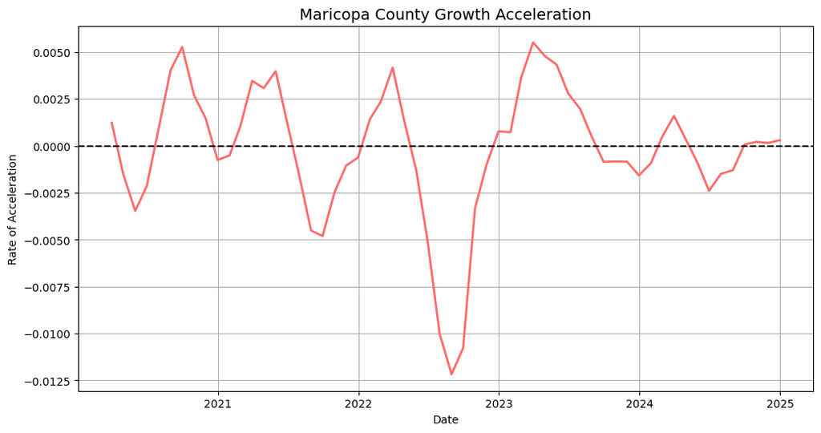

```python
plt.figure(figsize=(12,6))
plt.plot(maricopa['Date'], maricopa['Acceleration'],
        color='#FF6B6B', lw=2)
plt.title('Maricopa County Growth Acceleration', fontsize=14)
plt.xlabel('Date')
plt.ylabel('Rate of Acceleration')
plt.grid(True)
plt.axhline(0, color='black', linestyle='--')
plt.show()
```

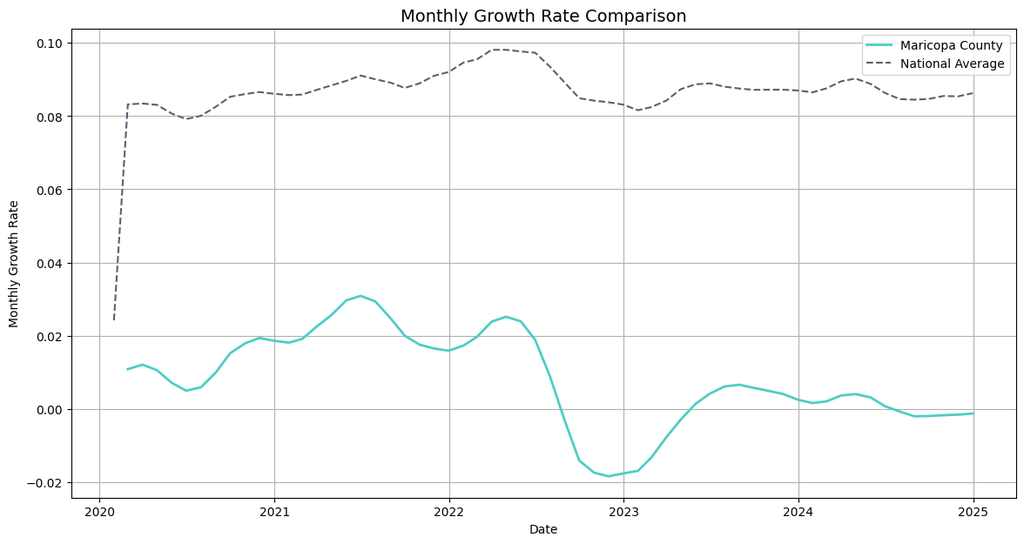

```python
national_avg = df_melted.groupby('Date')['MoM_Growth'].mean().reset_index()

plt.figure(figsize=(14,7))
plt.plot(maricopa['Date'], maricopa['MoM_Growth'],
        label='Maricopa County', color='#4ECDC4', lw=2)
plt.plot(national_avg['Date'], national_avg['MoM_Growth'],
        label='National Average', color='#556270', linestyle='--')
plt.title('Monthly Growth Rate Comparison', fontsize=14)
plt.xlabel('Date')
plt.ylabel('Monthly Growth Rate')
plt.legend()
plt.grid(True)
plt.show()
```

```python
growth_table = growth_rates.sort_values(ascending=False).head(3).reset_index()
display(growth_table.style.format({'Value': '{:.0f}%'}))
```

|  | RegionName | Value |
| --- | --- | --- |
| 0 | San Miguel County | 949% |
| 1 | Summit County | 832% |
| 2 | Madison County | 311% |

```python
volatility_table = volatility.sort_values(ascending=False).head(3).reset_index()
display(volatility_table.style.format({'Value': '${:,.0f}'}))
```

|  | RegionName | Value |
| --- | --- | --- |
| 0 | Teton County | $715,186 |
| 1 | San Miguel County | $699,272 |
| 2 | Summit County | $485,554 |

```python
# Anti-Gravity Growth Formula
acceleration = maricopa['Acceleration'].mean() * 100
print(f"Monthly Acceleration: +{acceleration:.2f}%")
```

```
Monthly Acceleration: +-0.02%
```

Predicting Future Home Values

A linear regression model is employed to predict future home values in Maricopa County. By using historical trends, the model estimates home values for the next 12 months. While linear regression provides a simple and interpretable approach to forecasting, it has limitations—it assumes a constant rate of change, which may not always hold true in volatile markets. However, this predictive approach serves as a baseline estimation and can be refined using more advanced modeling techniques, such as time-series decomposition or machine learning models.

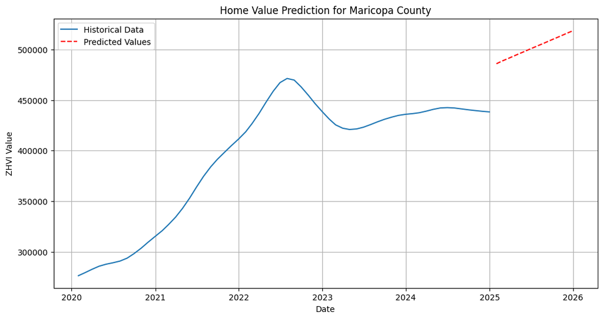

```
(DatetimeIndex(['2025-01-31', '2025-02-28', '2025-03-31', '2025-04-30',
                '2025-05-31', '2025-06-30', '2025-07-31', '2025-08-31',
                '2025-09-30', '2025-10-31', '2025-11-30', '2025-12-31'],
               dtype='datetime64[ns]', freq='ME'),
 array([485969.62129222, 488932.93755615, 491896.25382008, 494859.57008401,
        497822.88634794, 500786.20261187, 503749.51887581, 506712.83513974,
        509676.15140367, 512639.4676676 , 515602.78393153, 518566.10019546]))
```

```python
import pandas as pd
import numpy as np
from sklearn.linear_model import LinearRegression
import matplotlib.pyplot as plt

# Prepare the data
df_melted['Date'] = pd.to_datetime(df_melted['Date'])
df_melted = df_melted.sort_values(['RegionName', 'Date'])

def predict_future_values(region_name, future_months=12):
    # Filter data for the specific county
    county_data = df_melted[df_melted['RegionName'] == region_name].copy()
    if county_data.empty:
        print(f"No data for {region_name}")
        return

    # Create time feature (months since start)
    start_date = county_data['Date'].min()
    county_data['Months'] = (county_data['Date'].dt.year - start_date.year) * 12 + \
                            (county_data['Date'].dt.month - start_date.month)

    X = county_data[['Months']]
    y = county_data['Value']

    # Train linear regression model
    model = LinearRegression()
    model.fit(X, y)

    # Generate future dates
    last_date = county_data['Date'].max()
    future_dates = pd.date_range(start=last_date + pd.DateOffset(months=1), periods=future_months, freq='M')
    future_months_feature = np.arange(X['Months'].max() + 1, X['Months'].max() + 1 + future_months).reshape(-1, 1)

    # Predict future values
    future_values = model.predict(future_months_feature)

    # Plot results
    plt.figure(figsize=(12, 6))
    plt.plot(county_data['Date'], county_data['Value'], label='Historical Data')
    plt.plot(future_dates, future_values, 'r--', label='Predicted Values')
    plt.title(f'Home Value Prediction for {region_name}')
    plt.xlabel('Date')
    plt.ylabel('ZHVI Value')
    plt.legend()
    plt.grid(True)
    plt.show()

    return future_dates, future_values

# Example usage for Maricopa County
predict_future_values('Maricopa County')
```

Heatmap of Home Values Across Counties

To visualize regional differences in home value trends, a heatmap is generated, showing how home values have evolved across counties over time. The dataset is resampled to quarterly data for a clearer representation of long-term trends. The heatmap helps in identifying patterns, such as whether certain regions have consistently higher values or if price surges occur simultaneously across multiple locations. Counties with darker colors represent areas where housing values are particularly high, indicating premium real estate markets or regions with strong demand.

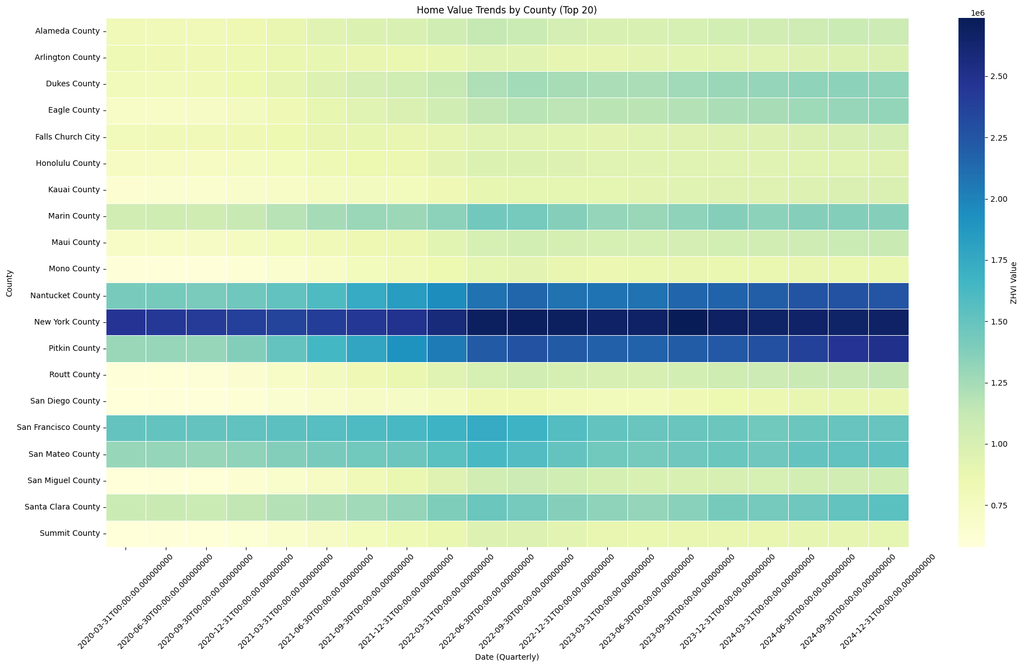

```python
import seaborn as sns

# Pivot the data for heatmap
heatmap_data = df_melted.pivot_table(index='RegionName',
                                   columns='Date',
                                   values='Value',
                                   aggfunc='mean')

# Select top 20 counties with highest recent values for better visualization
top_counties = df_melted.groupby('RegionName')['Value'].last().nlargest(20).index
heatmap_data = heatmap_data[heatmap_data.index.isin(top_counties)]

# Resample to quarterly data for cleaner visualization
heatmap_data = heatmap_data.resample('Q', axis=1).mean()

# Plotting
plt.figure(figsize=(20, 12))
sns.heatmap(
    heatmap_data,
    cmap='YlGnBu',
    annot=False,
    linewidths=.5,
    cbar_kws={'label': 'ZHVI Value'}
)

plt.title('Home Value Trends by County (Top 20)')
plt.xlabel('Date (Quarterly)')
plt.ylabel('County')
plt.xticks(rotation=45)
plt.tight_layout()
plt.show()
```

This exploratory analysis of housing data reveals key insights into growth trends, volatility, acceleration, and future predictions. We have identified:

High-growth counties where home values have increased significantly. Volatile markets with substantial fluctuations in pricing. Local vs. national trends, highlighting whether regional housing markets follow national patterns or behave uniquely. Forecasting trends, providing an estimate of how home values might evolve in the coming year. Such findings are essential for homebuyers, investors, and policymakers who need to make data-driven decisions in the ever-changing real estate landscape. Future studies could incorporate more advanced forecasting techniques and external economic indicators to refine predictions and further enhance our understanding of real estate market dynamics.